# Reproducible Research: Peer Assessment 1

Jordan Woloschuk

7/8/2019

## Introduction

This assignment showcases my ability to conduct some data analysis and make use of R markdown and knitr. This project will makes use of data from a personal activity monitoring device. This device collects data at 5 minute intervals through out the day. The data consists of two months of data from an anonymous individual collected during the months of October and November, 2012 and include the number of steps taken in 5 minute intervals each day.

This dataset can be found here: [Activity monitoring dataset](https://d396qusza40orc.cloudfront.net/repdata%2Fdata%2Factivity.zip)

This assignment contains a number of steps, shown below:

## Loading and Preprocessing the Data

### 1) Loading the data

```r
# Load necessary packages
library(dplyr)

# Set working directory, save the zip file URL, and the zip file name
setwd("~/GitHub/RepData_PeerAssessment1")
zip_url <- "https://d396qusza40orc.cloudfront.net/repdata%2Fdata%2Factivity.zip"
zip_file <- "repdata_data_activity.zip"

# Names of the csv file that is contained in the zip file
activity_csv <- "activity.csv"

# Checks if the above file exists. If not, checks to see if the zip file is in
# the directory, if not, then downloads the zip file.
# The zip file is then unzipped and the zipfile is then removed from the working
# directory.

if (!(file.exists(activity_csv))){
        if (!file.exists(zip_file)) {
                download.file(zip_url, zip_file, method = "curl")
        }

        # Unzip the zip file
        unzip(zip_file)

}

activity_data <- read.csv(activity_csv, na.strings = "NA")
```

### 2) Process/transform the data

```r
# Change date class from default Factor class to Date class
activity_data <- activity_data %>% mutate(date = as.Date(date, format= "%Y-%m-%d"))

str(activity_data)
```

```
## 'data.frame':    17568 obs. of  3 variables:
##  $ steps   : int  NA NA NA NA NA NA NA NA NA NA ...
##  $ date    : Date, format: "2012-10-01" "2012-10-01" ...
##  $ interval: int  0 5 10 15 20 25 30 35 40 45 ...
```

## Mean Total Number of Steps Taken per Day

### 1) Calculate the total number of steps taken per day

```r
# Calculate the total sum of steps per day
steps_per_day <- aggregate(steps ~ date, activity_data, sum)
```

### 2) Histogram of the total number of steps taken each day

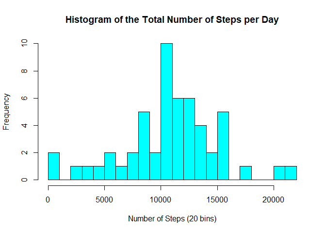

```r
# Plot a histogram with 20 breaks (bins of 1,000 steps)
hist(steps_per_day$steps, main = "Histogram of the Total Number of Steps per Day",
     xlab = "Number of Steps (20 bins)", col = "cyan", breaks = 20)
```

```r
# Calculate the total mean and median using the steps per day
total_mean <- mean(steps_per_day$steps)
total_median <- median(steps_per_day$steps)
```

## Average Daily Activity Pattern

### 1) Time series plot of the 5-minute interval and the average number of steps taken, averaged across all days

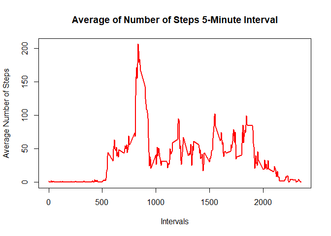

```r
mean_steps_per_interval <- aggregate(steps ~ interval, activity_data, mean)


# Plot of the average number of steps per 5-Minute Interval
with(mean_steps_per_interval, plot(interval,steps, col = "red", typ = "l",
                              lwd = 2, main = "Average of Number of Steps 5-Minute Interval",
                              xlab = "Intervals", ylab = "Average Number of Steps"))
```

```r
# Arrange the dataframe with descending average number of steps
sorted_mean_steps_per_interval <- arrange(mean_steps_per_interval,-steps)
max_steps <- sorted_mean_steps_per_interval$steps[1]
max_interval <- sorted_mean_steps_per_interval$interval[1]
```

- The maximum average number of steps that occurs during a 5-minute interval is: 206.1698113  
  This coresponds to interval: 835

## Imputing Missing Values

### 1) Total number of missing values in the datase

```r
count_na <- sum(is.na(activity_data$steps))
```

- There are 2304 days/intervals where there is missing values.

### 2) Imputing missing values & 3) New dataset without missing data

```r
imputted_activity_data <- activity_data

# Repeat the mean steps per interval 61 times (17568 total observations / 288 intervals)
rep_mean_time_intervals <- rep(mean_steps_per_interval$steps, 61)

# For loop and if statement to check if steps = "NA", if so, replace with mean interval time
for (i in 1:nrow(imputted_activity_data)){
  if(is.na(imputted_activity_data$steps[i]))
    {imputted_activity_data$steps[i] <- rep_mean_time_intervals[i]}
}

# Check if all NA's have been removed
sum(is.na(imputted_activity_data$steps))
```

```
## [1] 0
```

## 4a) Make a histogram of the total number of steps taken each day

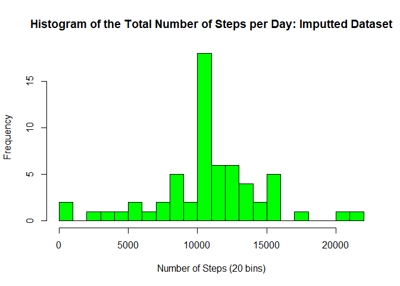

```r
# Calculate the total sum of steps per day
imputted_steps_per_day <- aggregate(steps ~ date, imputted_activity_data, sum)

# Plot a histogram with 20 breaks (bins of 1,000 steps)
hist(imputted_steps_per_day$steps, main =
       "Histogram of the Total Number of Steps per Day: Imputted Dataset",
     xlab = "Number of Steps (20 bins)", col = "green", breaks = 20)
```

```r
# Not clear if we are to calculate the total mean and median across all days
imputted_total_mean <- mean(imputted_steps_per_day$steps)
imputted_total_median <- median(imputted_steps_per_day$steps)
```

## 4c) How these new values differ compared to the the first part of the assignment

```r
# Not clear if we are to calculate the total mean and median across all days
dif_mean <- imputted_total_mean - total_mean
dif_median <- imputted_total_median - total_median
```

- Imputted dataset mean is the same as the mean from the first part: A difference of: 0
- Imputted dataset median is slightly greater compared to median from the first part by 1.1886792  
  This indicates that it is reasonable to remove NA values from this analysis

## Differences in Activity Patterns Between Weekdays and Weekends

### 1) Create a new factor variable in the dataset with two levels – “weekday” and “weekend”

```r
# Create new colum with the day of the week
# The wday component of a POSIXlt object is the numeric weekday (0-6 starting on Sunday)
imputted_activity_data$day <- as.POSIXlt(imputted_activity_data$date)$wday

# Create new factor based on if the day is a weekday or a weekend
imputted_activity_data$day.type <- ifelse(imputted_activity_data$day %in% c(0,6), "weekend", "weekday")
```

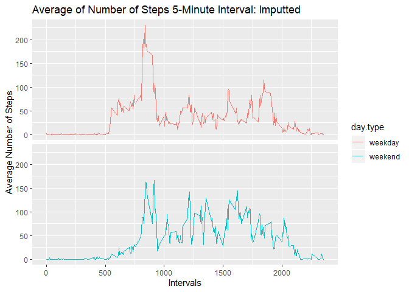

```r
library(ggplot2)

imputted_mean_steps_per_interval <- aggregate(steps ~ interval + day.type, imputted_activity_data, mean)


# Plot of the average number of steps per 5-Minute Interval

g_plot <- ggplot(imputted_mean_steps_per_interval, aes(interval, steps, color = day.type))
g_plot <- g_plot + geom_line() + facet_grid(day.type ~ .) + xlab("Intervals") +
          ylab("Average Number of Steps") + ggtitle("Average of Number of Steps 5-Minute Interval: Imputted") +
          theme(strip.text.y = element_blank())

print(g_plot)
```